# Análises Amblypygi

Gabi, PM, Diogo, Gustavo, Thiago

2024-06-10

# 1 Packages

```r
library(tidyverse)
library(ape)
library(phytools)
library(PVR)
library(factoextra)
library(nlme)
library(geiger)
library(dispRity)
library(rr2)
source("brutal.R")
source("distance2.R")
source("pglm3.4.R")
library(lsr)
library(ggtree)
library(V.PhyloMaker)
library(tmap)
library(sf)
```

# 2 Data imput and manipulation

```r
dados <- read.csv("data_Miranda_et_al_2021_final.csv", sep = ";")
tree <- read.tree("arvore_calibrada.tre")

tree <- multi2di(tree)
tree$edge.length[tree$edge.length == 0] <- 0.01
tree<-phangorn::nnls.tree(cophenetic(tree),tree,rooted=TRUE)
tree <-makeNodeLabel(tree,prefix="n")

# Create a new column with species names matching tree names format
dados <- dados %>% mutate(Species_phylo = paste(substr(Species, 1, 1),
                                                sub("^\\w+\\s(\\w+).*", "\\1", Species),
                                                sep = "_"))
# Create dataset
data_fem <- dados %>%
  filter(Sex == "F") %>% # Filter for females present in the phylogenetic tree
  group_by(Species, Sex) %>%
  mutate(Mean_Carapace_width = mean(Carapace_width), # Get mean values for the other traits (needed for body shape)
         Mean_Pedipald_femur_length = mean(Pedipald_femur_length),
         Mean_Pedipald_patella_length = mean(Pedipald_patella_length)) %>%
  ungroup() %>%
  dplyr::select(Species, Species_phylo, N_individuals, Mean_Carapace_length, SE_Carapace_length, Mean_Carapace_width, Mean_Pedipald_femur_length, Mean_Pedipald_patella_length, Habit, Temp_mean, Temp_seasonality, Temp_range, Precip_annual, Precip_seasonality, meanLongitude, meanLatitude, Realm) %>%
  distinct() %>%
  group_by(Species) %>% slice_head() %>% ungroup() %>% # See "TODO" below
  mutate(Habit = ifelse(Habit == "nest", "forest", Habit)) # We transformed nest to forest because we only have one

# Wich species are in the phylogeny but missing in our dataset?
sp <- data_fem$Species_phylo
my.species<-as.matrix(sp)
comparison<-name.check(tree,my.species,data.names=my.species[,1])
comparison$tree_not_data
```

```
##  [1] "C_australianus" "C_carineae"     "C_cubensis"     "C_gertschi"
##  [5] "C_goitaca"      "C_papuanus"     "diadema1479"    "giganteus3509"
##  [9] "longipes1483"   "S_abbatei"      "S_bispinosus"   "S_pakistanus"
## [13] "S_rahmadii"     "S_seychellarum" "S_socotranus"   "S_sp_Lombok"
## [17] "S_sp_Sumbawa"   "sbordonii3757"  "singaporae4761" "sp3Bali11594"
## [21] "SpGrenada9054"  "W_davidovi"
```

```r
comparison$data_not_tree
```

```
##  [1] "C_acosta"           "C_bahoruco"         "C_bordoni"
##  [4] "C_brescoviti"       "C_bromeliaea"       "C_bruneti"
##  [7] "C_caatingae"        "C_camachoi"         "C_carajas"
## [10] "C_centralis"        "C_desirade"         "C_loko"
## [13] "C_longipes"         "C_longitarsus"      "C_madagascariensis"
## [16] "C_magua"            "C_martinicensis"    "C_orientalis"
## [19] "C_pardillalensis"   "C_perezassoi"       "C_ricardoi"
## [22] "C_schirchii"        "C_susuwa"           "C_tingomaria"
## [25] "C_troglobius"       "C_tronchonii"       "S_cavernicola"
## [28] "S_curioi"           "S_dhofarensis"      "S_mardua"
## [31] "S_monodenticulatus" "S_rahmadi"          "S_stygochthobius"
```

```r
position<-which(tree$tip.label == "S_rahmadii")
tree$tip.label[position]<-"S_rahmadi"
position<-which(tree$tip.label == "longipes1483")
tree$tip.label[position]<-"C_longipes"

comparison<-name.check(tree,my.species,data.names=my.species[,1])
comparison$tree_not_data
```

```
##  [1] "C_australianus" "C_carineae"     "C_cubensis"     "C_gertschi"
##  [5] "C_goitaca"      "C_papuanus"     "diadema1479"    "giganteus3509"
##  [9] "S_abbatei"      "S_bispinosus"   "S_pakistanus"   "S_seychellarum"
## [13] "S_socotranus"   "S_sp_Lombok"    "S_sp_Sumbawa"   "sbordonii3757"
## [17] "singaporae4761" "sp3Bali11594"   "SpGrenada9054"  "W_davidovi"
```

```r
comparison$data_not_tree
```

```
##  [1] "C_acosta"           "C_bahoruco"         "C_bordoni"
##  [4] "C_brescoviti"       "C_bromeliaea"       "C_bruneti"
##  [7] "C_caatingae"        "C_camachoi"         "C_carajas"
## [10] "C_centralis"        "C_desirade"         "C_loko"
## [13] "C_longitarsus"      "C_madagascariensis" "C_magua"
## [16] "C_martinicensis"    "C_orientalis"       "C_pardillalensis"
## [19] "C_perezassoi"       "C_ricardoi"         "C_schirchii"
## [22] "C_susuwa"           "C_tingomaria"       "C_troglobius"
## [25] "C_tronchonii"       "S_cavernicola"      "S_curioi"
## [28] "S_dhofarensis"      "S_mardua"           "S_monodenticulatus"
## [31] "S_stygochthobius"
```

```r
# Remove species without data from the phylogenetic tree
tree <- drop.tip(tree, comparison$tree_not_data)
# Filter for females present in the phylogenetic t

data_fem <- data_fem %>%
  filter(Species_phylo %in% tree$tip.label) %>%
  mutate(Genero = word(Species, 1))
# Put species as row names (needed for some analyses below)

data_fem_rn <- data_fem %>% column_to_rownames("Species_phylo")
```

# 3 Exploration

## 3.1 Tree

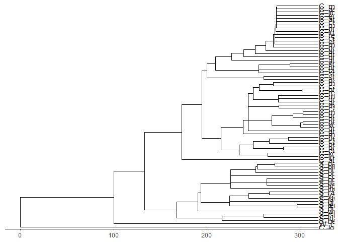

## 3.2 Map

```
##  [1] "Latitude"                     "Longitude"
##  [3] "Species"                      "N_individuals"
##  [5] "Mean_Carapace_length"         "SE_Carapace_length"
##  [7] "Mean_Carapace_width"          "Mean_Pedipald_femur_length"
##  [9] "Mean_Pedipald_patella_length" "Habit"
## [11] "Temp_mean"                    "Temp_seasonality"
## [13] "Temp_range"                   "Precip_annual"
## [15] "Precip_seasonality"           "meanLongitude"
## [17] "meanLatitude"                 "Realm"
## [19] "Genero"
```

```
## Simple feature collection with 70 features and 2 fields
## Geometry type: POINT
## Dimension:     XY
## Bounding box:  xmin: -90.33987 ymin: -23.73333 xmax: 166.5461 ymax: 35.01652
## Geodetic CRS:  WGS 84
## First 10 features:
##                 Genero       Habit                    geometry
## C_acaraje     Charinus        cave POINT (-39.39116 -15.41768)
## C_africanus   Charinus      forest   POINT (6.625353 0.285617)
## C_aguayoi     Charinus      forest  POINT (-66.40519 18.30628)
## C_alagoanus   Charinus      forest POINT (-35.89883 -9.279825)
## C_apiaca      Charinus cave/forest   POINT (-41.5664 -21.1538)
## C_asturius    Charinus      forest POINT (-45.31667 -23.73333)
## C_belizensis  Charinus cave/forest   POINT (-88.68219 17.1658)
## C_bichuetteae Charinus        cave POINT (-53.65806 -5.878889)
## C_bonaldoi    Charinus      forest POINT (-50.19093 -1.279506)
## C_brasilianus Charinus cave/forest POINT (-40.34543 -19.92675)
```

```
## Simple feature collection with 176 features and 0 fields
## Geometry type: MULTIPOLYGON
## Dimension:     XY
## Bounding box:  xmin: -180 ymin: -55.61183 xmax: 180 ymax: 83.64513
## Geodetic CRS:  WGS 84
## First 10 features:
##                          geometry
## 1  MULTIPOLYGON (((180 -16.067...
## 2  MULTIPOLYGON (((33.90371 -0...
## 3  MULTIPOLYGON (((-8.66559 27...
## 4  MULTIPOLYGON (((-122.84 49,...
## 5  MULTIPOLYGON (((-122.84 49,...
## 6  MULTIPOLYGON (((87.35997 49...
## 7  MULTIPOLYGON (((55.96819 41...
## 8  MULTIPOLYGON (((141.0002 -2...
## 9  MULTIPOLYGON (((141.0002 -2...
## 10 MULTIPOLYGON (((-68.63401 -...
```

```
## Simple feature collection with 70 features and 2 fields
## Geometry type: POINT
## Dimension:     XY
## Bounding box:  xmin: -8534776 ymin: -2538330 xmax: 15396220 ymax: 3745082
## Projected CRS: +proj=robin +lon_0=0 +x_0=0 +y_0=0 +ellps=WGS84 +datum=WGS84 +units=m +no_defs
## First 10 features:
##                 Genero       Habit                   geometry
## C_acaraje     Charinus        cave  POINT (-3682195 -1648950)
## C_africanus   Charinus      forest  POINT (625938.9 30547.29)
## C_aguayoi     Charinus      forest   POINT (-6179680 1957890)
## C_alagoanus   Charinus      forest POINT (-3377959 -992495.2)
## C_apiaca      Charinus cave/forest  POINT (-3849516 -2262442)
## C_asturius    Charinus      forest  POINT (-4176860 -2538330)
## C_belizensis  Charinus cave/forest   POINT (-8268035 1835913)
## C_bichuetteae Charinus        cave POINT (-5060097 -628758.4)
## C_bonaldoi    Charinus      forest POINT (-4741357 -136845.7)
## C_brasilianus Charinus cave/forest  POINT (-3744328 -2131202)
```

```
## Simple feature collection with 176 features and 0 fields
## Geometry type: GEOMETRY
## Dimension:     XY
## Bounding box:  xmin: -16810130 ymin: -5900074 xmax: 16810130 ymax: 8343004
## Projected CRS: +proj=robin +lon_0=0 +x_0=0 +y_0=0 +ellps=WGS84 +datum=WGS84 +units=m +no_defs
## First 10 features:
##                          geometry
## 1  MULTIPOLYGON (((16625566 -1...
## 2  POLYGON ((3202918 -101604.3...
## 3  POLYGON ((-791398.1 2957887...
## 4  MULTIPOLYGON (((-10435280 5...
## 5  MULTIPOLYGON (((-14377388 2...
## 6  POLYGON ((7202132 5245560, ...
## 7  POLYGON ((4839886 4415250, ...
## 8  MULTIPOLYGON (((13647711 -4...
## 9  MULTIPOLYGON (((11328212 -1...
## 10 MULTIPOLYGON (((-5468034 -5...
```

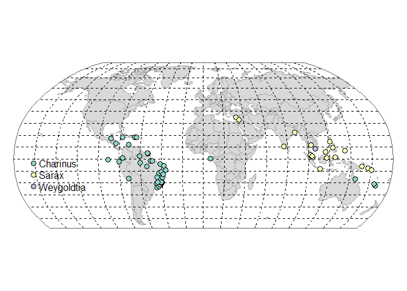

## 3.3 Habit

```
##        cave cave/forest        city      forest
##          24           6           5          35
```

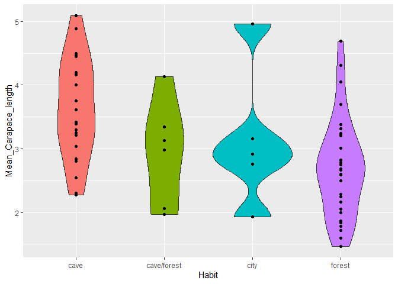

# Analyses

## 3.4 Question 1: Is mean body size different among habits?

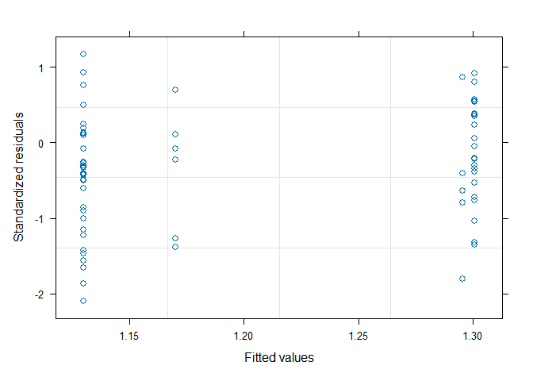

```r
# Full model
pgls_hab <- gls(log(Mean_Carapace_length) ~ Habit,
                cor=corPagel(1, tree, form = ~ Species_phylo),
                data=data_fem)
plot(pgls_hab) # Is this reliable?
```

```r
# Is habitat related to body size?
result<-anova(pgls_hab) #aqui parou de aparecer o valor de p nessa visualização '-'
result
```

```
## Denom. DF: 66
##             numDF  F-value p-value
## (Intercept)     1 40.68920  <.0001
## Habit           3  3.03022  0.0354
```

```r
rr2::R2_pred(pgls_hab)
```

```
## [1] 0.5240361
```

```r
# R2_pred calculate partial and total R2s for LMM, GLMM, PGLS, and PGLMM using R2_pred, an R2 based on the variance of the difference between the observed and predicted values of a fitted model.
```

> **Result 1:** Body size is marginally linked to species habits. Apparently, the differece is driven by cave species vs forest species (see below).

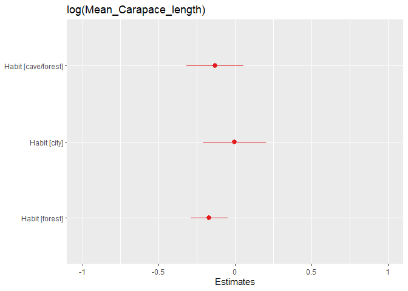

```r
# Plot estimates
sjPlot::plot_model(pgls_hab)
```

> Based on the plot, species from forests are smaller than species from caves (omitted).

```r
## Traitgram
col_hab <- setNames(data_fem$Habit, data_fem$Species_phylo) # Vector of habitats with species
filocommap <- make.simmap(tree, col_hab, "ER")
```

```
## make.simmap is sampling character histories conditioned on
## the transition matrix
##
## Q =
##                     cave  cave/forest         city       forest
## cave        -0.007745955  0.002581985  0.002581985  0.002581985
## cave/forest  0.002581985 -0.007745955  0.002581985  0.002581985
## city         0.002581985  0.002581985 -0.007745955  0.002581985
## forest       0.002581985  0.002581985  0.002581985 -0.007745955
## (estimated using likelihood);
## and (mean) root node prior probabilities
## pi =
##        cave cave/forest        city      forest
##        0.25        0.25        0.25        0.25
```

```
## Done.
```

```r
bs_ws <- setNames(data_fem$Mean_Carapace_length, data_fem$Species_phylo) # Vector of body sizes with species names
phenogram(filocommap, bs_ws)
```

```
## Optimizing the positions of the tip labels...
```

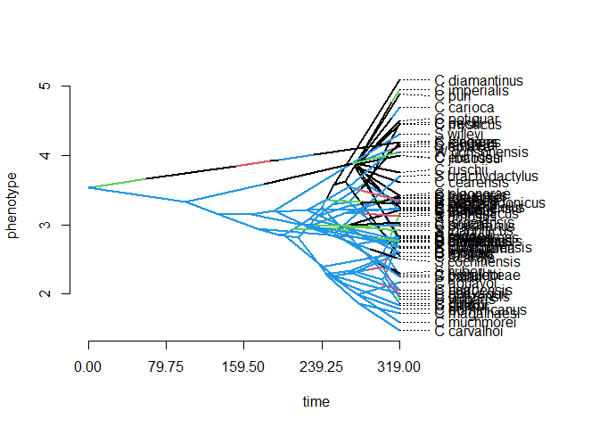

> The traitgram shows that cave (black) species tend to form a distinct cluster *blue = forest* black = cave *green = city* red = cave/forest

## 3.5 Question 2: What are the relative roles of phylogeny and climate in explaining whip-spider body size?

```r
# Calculate phylogenetic and spatial matrices
vcv_whip <- vcv.phylo(tree) # Phylogenetic Variance-covariance matrix
dist_whip <- dist.mat(data_fem$meanLatitude, data_fem$meanLongitude, rwnms = data_fem$Species_phylo) # Geographical distance matrix
```

**A. Only Space**

```r
fm <- pglmSpatial(Mean_Carapace_length ~ 1, data_fem_rn, vcv_whip, dist_whip)
summary(fm)
```

```
##
##
## --------------------------------------------------------
## Summary of Generalised Least Squares, correcting for
## Phylogeny:
##
## Number of parameters =  1
## Number of data points =  65
##
## Lambda statistic =  1
## Maximised log-likelihood =  -76.35238
##
## Model AIC =  154.7125
## Model AICc =  154.776
##
## Null Mean Square =  0.4537327
## Residual Mean Square =  0.4537327
##
## Raw R^2 =  0
## Adjusted R^2 =  0
## F statistic =  NaN  P model =  NaN
##
## Summary of coefficients:
##
## Term     Estimate        Std Err     T-value P
## (Intercept)  3.545595     0.8532265   4.155514    9.81858e-05
##
##
## --------------------------------------------------------
```

**B. Only Climate**

```r
fmsp <- pglm(Mean_Carapace_length ~ Temp_mean + Temp_seasonality + Temp_range + Precip_annual + Precip_seasonality, data=data_fem_rn, vcv_whip)
fmsp
```

```
##
##
## --------------------------------------------------------
## Summary of Generalised Least Squares, correcting for
## Phylogeny:
##
## Number of parameters =  6
## Number of data points =  65
##
## Lambda statistic =  1
## Maximised log-likelihood =  -75.15201
##
## Model AIC =  167.5993
## Model AICc =  169.0475
##
## Null Mean Square =  0.4537327
## Residual Mean Square =  0.43728
##
## Raw R^2 =  0.03626077
## Adjusted R^2 =  -0.04541204
## F statistic =  0.4439761  P model =  0.815934
##
## Summary of coefficients:
##
## Term     Estimate        Std Err     T-value P
## (Intercept)  2.96104      1.870936    1.582652    0.1188472
## Temp_mean    -0.0004498547    0.005336105     -0.08430394     0.9331002
## Temp_seasonality     0.0001077345     0.0001951371    0.5520967   0.5829675
## Temp_range   0.003121907      0.006137395     0.5086697   0.6128807
## Precip_annual    5.17645e-05      0.0001512295    0.3422911   0.7333482
## Precip_seasonality   8.916291e-05     0.004687522     0.01902133      0.9848883
##
##
## --------------------------------------------------------
```

```r
# The above fits a GLM, correcting for phylogeny, with the option of setting the value of lambda, the index of phylogenetic dependence (default is 1.0)
```

**C. Only Climate but optimizing the value of lambda**

```r
fm1 <- pglmEstLambda(Mean_Carapace_length ~ Temp_mean + Temp_seasonality + Temp_range + Precip_annual + Precip_seasonality, data_fem_rn, vcv_whip)
fm1
```

```
##
##
## --------------------------------------------------------
## Summary of Generalised Least Squares, correcting for
## Phylogeny:
##
## Number of parameters =  6
## Number of data points =  65
##
## Lambda statistic =  0.8066796
##      Test of Lambda = 0: chisq =  13.30048  P =  0.0002653387
##      Test of Lambda = 1: chisq =  4.639543  P =  0.03124332
## Maximised log-likelihood =  -72.83224
##
## Model AIC =  162.9597
## Model AICc =  164.408
##
## Null Mean Square =  0.2524649
## Residual Mean Square =  0.2415931
##
## Raw R^2 =  0.04306284
## Adjusted R^2 =  -0.03803353
## F statistic =  0.5310082  P model =  0.751896
##
## Summary of coefficients:
##
## Term     Estimate        Std Err     T-value P
## (Intercept)  4.003493     1.71406     2.335679    0.02292708
## Temp_mean    -0.004009101     0.005170764     -0.7753402      0.4412353
## Temp_seasonality     2.600109e-05     0.0001897009    0.1370636   0.8914472
## Temp_range   0.002631186      0.006182575     0.4255809   0.6719617
## Precip_annual    4.111468e-05     0.0001456567    0.2822711   0.7787235
## Precip_seasonality   -0.0003768938    0.004563869     -0.08258208     0.9344634
##
##
## --------------------------------------------------------
```

```r
# The above optimises the value of lambda for a given dataset and phylogeny. The return is the model at the ML value of lambda together with the ML estimate of lambda and the maximised log-likelihood. Also returned are the logLikelihoods at Lambda = 0 and Lambda = 1.0
```

> B and C had the same results (i.e., non-significant)

**D. Climate + Space**

```r
spacewhip <- pglmSpatial(Mean_Carapace_length ~ Temp_mean + Temp_seasonality + Temp_range + Precip_annual + Precip_seasonality, data_fem_rn, vcv_whip, dist_whip)
spacewhip
```

```
##
##
## --------------------------------------------------------
## Summary of Generalised Least Squares, correcting for
## Phylogeny:
##
## Number of parameters =  6
## Number of data points =  65
##
## Lambda statistic =  1
## Maximised log-likelihood =  -75.15201
##
## Model AIC =  167.5993
## Model AICc =  169.0475
##
## Null Mean Square =  0.4537327
## Residual Mean Square =  0.43728
##
## Raw R^2 =  0.03626077
## Adjusted R^2 =  -0.04541204
## F statistic =  0.4439761  P model =  0.815934
##
## Summary of coefficients:
##
## Term     Estimate        Std Err     T-value P
## (Intercept)  2.96104      1.870936    1.582652    0.1188472
## Temp_mean    -0.0004498547    0.005336105     -0.08430394     0.9331002
## Temp_seasonality     0.0001077345     0.0001951371    0.5520967   0.5829675
## Temp_range   0.003121907      0.006137395     0.5086697   0.6128807
## Precip_annual    5.17645e-05      0.0001512295    0.3422911   0.7333482
## Precip_seasonality   8.916291e-05     0.004687522     0.01902133      0.9848883
##
##
## --------------------------------------------------------
```

**E. Climate + Space, but co-estimates lambda and phi whilst fitting a pGLM**

```r
fm2 <- pglmSpatialFit( Mean_Carapace_length ~ Temp_mean + Temp_seasonality + Temp_range + Precip_annual + Precip_seasonality, data_fem_rn, vcv_whip, dist_whip, plotit = TRUE)
fm2
```

```
##
##
## --------------------------------------------------------
## Summary of Generalised Least Squares, correcting for
## Phylogeny:
##
## Number of parameters =  6
## Number of data points =  65
##
## Lambda statistic =  0.6846347
##      Test of Lambda = 0: chisq =    P =
##      Test of Lambda = 1: chisq =    P =
## Maximised log-likelihood =  -71.5997
##
## Model AIC =  160.4946
## Model AICc =  161.9429
##
## Null Mean Square =  0.2519727
## Residual Mean Square =  0.2364577
##
## Raw R^2 =  0.06157424
## Adjusted R^2 =  -0.01795337
## F statistic =  0.7742499  P model =  0.5721694
##
## Summary of coefficients:
##
## Term     Estimate        Std Err     T-value P
## (Intercept)  3.781192     1.707007    2.215101    0.03062634
## Temp_mean    -0.004240681     0.005094932     -0.8323331      0.4085774
## Temp_seasonality     -5.814954e-05    0.0001900395    -0.3059866      0.7606919
## Temp_range   0.004615202      0.006070148     0.7603114   0.4500962
## Precip_annual    5.173159e-06     0.0001441507    0.03588717      0.9714935
## Precip_seasonality   -4.204611e-05    0.004470247     -0.009405767    0.9925271
##
##
## --------------------------------------------------------
```

> **Result 2:** Body size is not affected by climate

## 3.6 Question 3. Which macroevolutionary model is the best explanation for whip-spider body size variation?

#### 3.6.0.1 3.1. Including fossil as root prior (fitcontinuousMCMC)

```r
bs_ws <- setNames(data_fem$Mean_Carapace_length, data_fem$Species_phylo) # Vector of body sizes with species names

# We used the SE of Charinus bonaldoi (0.09526254) as the fossil SE (C_bonaldoi has the highest number of individuals measured)

# A. Brownian motion

fitContinuousMCMC(tree, bs_ws, model = "BM", Ngens = 10000, sampleFreq =100, printFreq = 100, root.prior = c(3.8, 0.09526254, "normal"), outputName ="whip_BM")

bm.res <- read.table("whip_BM_model_params.txt", header= TRUE)
#head(bm.res)

# B. BM with a directional trend
fitContinuousMCMC(tree, bs_ws, model = "Trend", Ngens = 10000, sampleFreq =100, printFreq = 100, root.prior = c(3.8, 0.09526254, "normal"), outputName ="whip_Trend")
trend.res <- read.table("whip_Trend_model_params.txt", header= TRUE)
#head(trend.res)

# C. Single stationary peak, or single-optimum
fitContinuousMCMC(tree, bs_ws, model = "SSP", Ngens = 10000, sampleFreq =100, printFreq = 100, root.prior = c(3.8, 0.09526254, "normal"), outputName ="whip_SSP")

SSP.res <- read.table("whip_SSP_model_params.txt", header= TRUE)
#head(SSP.res)

# D. Accelerating-Decelerating evolution where the change in rate is exponential with respect to time
fitContinuousMCMC(tree, bs_ws, model = "ACDC.exp", Ngens = 10000, sampleFreq =100, printFreq = 100, root.prior = c(3.8, 0.09526254, "normal"), outputName ="whip_ACDC_exp")

ACDC.exp.res <- read.table("whip_ACDC_exp_model_params.txt", header= TRUE)
#head(ACDC.exp.res)

# E. Accelerating-Decelerating evolution where the change in rate is linear with respect to time
fitContinuousMCMC(tree, bs_ws, model = "ACDC.lin", Ngens = 10000, sampleFreq =100, printFreq = 100, root.prior = c(3.8, 0.09526254, "normal"), outputName ="whip_ACDC_lin")

ACDC.lin.res <- read.table("whip_ACDC_lin_model_params.txt", header= TRUE)
#head(ACDC.lin.res)
```

**Produce trace plots of logLk scores**

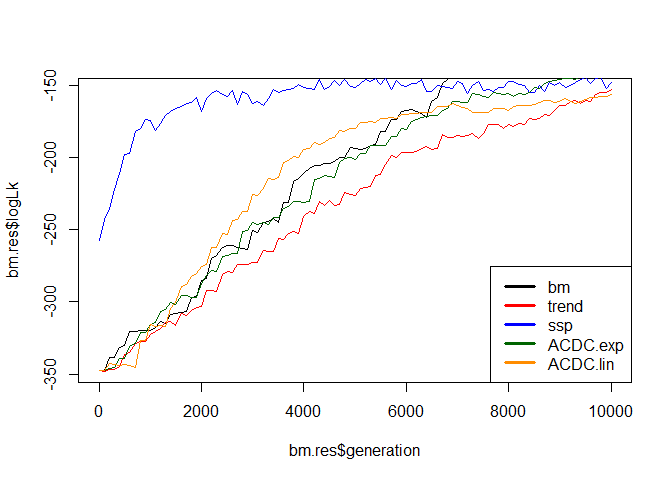

```r
{
plot(bm.res$generation, bm.res$logLk, type = "l",
     ylim = c(min(bm.res$logLk), max = max(trend.res$logLk)))

#lines(trend.res$generation, trend.res$logLk, col = "red")
lines(trend.res$generation, trend.res$logLk, col = "red")
lines(SSP.res$generation, SSP.res$logLk, col = "blue")
lines(ACDC.exp.res$generation, ACDC.exp.res$logLk, col = "darkgreen")
lines(ACDC.lin.res$generation, ACDC.lin.res$logLk, col = "darkorange")

legend("bottomright", c("bm", "trend", "ssp", "ACDC.exp", "ACDC.lin"), lwd = 3, col = c("black", "red", "blue", "darkgreen", "darkorange"))
}
```

Remove burn-in and get Akaike’s Information Criterion (AIC) for each model

```r
# A. Brownian motion
bm.AIC <- bm.res %>%
  filter(generation >= 4000) %>% # Remove burn-in
  dplyr::select("logLk") %>%
  as_vector() %>%
  aicm()

# B. BM with a directional trend
trend.AIC <- trend.res %>%
  filter(generation >= 4000) %>% # Remove burn-in
  dplyr::select("logLk") %>%
  as_vector() %>%
  aicm()

# C. Single stationary peak, or single-optimum
SSP.AIC <- SSP.res %>%
  filter(generation >= 4000) %>% # Remove burn-in
  dplyr::select("logLk") %>%
  as_vector() %>%
  aicm()

# D. ACDC.exp
ACDC.exp.AIC <- ACDC.exp.res %>%
  filter(generation >= 4000) %>% # Remove burn-in
  dplyr::select("logLk") %>%
  as_vector() %>%
  aicm()

#E. ACDC.lin
ACDC.lin.AIC <- ACDC.lin.res %>%
  filter(generation >= 4000) %>% # Remove burn-in
  dplyr::select("logLk") %>%
  as_vector() %>%
  aicm()

# AIC values
mods <- data.frame(Model = c("Brownian motion (BM)", "BM with a directional trend", "Single stationary peak", "ACDC exponential", "ACDC linear"),
                   AIC = c(bm.AIC, trend.AIC, SSP.AIC, ACDC.exp.AIC, ACDC.lin.AIC)) %>%
  arrange(AIC)

## Akaike weights
mods_vector <- setNames(mods$AIC, mods$Model)
aicw(mods_vector)
```

```
##                                   fit     delta             w
## Single stationary peak       317.3019    0.0000  1.000000e+00
## ACDC linear                  524.3656  207.0638  1.088111e-45
## ACDC exponential            1590.2421 1272.9403 3.841755e-277
## BM with a directional trend 1653.2010 1335.8992 8.188117e-291
## Brownian motion (BM)        3137.3209 2820.0190  0.000000e+00
```

> **Result 3.1:** Single stationary peak is the best-suported model. “although we find support for constrained models of evolution, models invoking stabilizing selection around a single stationary peak require very weak selection, unrealistically small population sizes, or both.” (Harmon et al. 2010)

```r
bs_se <- setNames(data_fem$SE_Carapace_length, data_fem$Species_phylo)

# A. Brownian motion
bm <- fitContinuous(tree, bs_ws, SE = bs_se, model = "BM")
bm$opt$aic
```

```
## [1] 165.0685
```

```r
# B. Ornstein-Uhlenbeck model
ou <- fitContinuous(tree, bs_ws, SE = bs_se, model = "OU")
ou$opt$aic
```

```
## [1] 162.0023
```

```r
# C. Early-burst
eb <- fitContinuous(tree, bs_ws, SE = bs_se, model = "EB")
eb$opt$aic
```

```
## [1] 167.0692
```

```r
# D. rate_trend
rt <- fitContinuous(tree, bs_ws, SE = bs_se, model = "rate_trend")
rt$opt$aic
```

```
## [1] 164.1788
```

# 4 Disparity-through-time curve

```r
#data manipulation
traits_mult <- data_fem_rn[, c("Mean_Carapace_length", "Mean_Carapace_width", "Mean_Pedipald_femur_length", "Mean_Pedipald_patella_length")] %>%
  drop_na() # Remove species with missing traits (n = 5)

sp <- rownames(traits_mult)
my.species<-as.matrix(sp)
comparison2<-name.check(tree,my.species,data.names=my.species[,1])
comparison2$tree_not_data
```

```
## [1] "C_asturius"   "C_caribensis" "C_guto"       "C_palikur"    "C_reddelli"
```

```r
comparison2$data_not_tree
```

```
## character(0)
```

```r
pruned.tree2<-drop.tip(tree, comparison2$tree_not_data)

root_age <- max(node.depth.edgelength(tree))
pruned.tree2$root.time <- root_age

disparity_data<-dispRity.through.time(traits_mult, pruned.tree2, time=3, metric = c(sum, variances))
bt<-as.data.frame(branching.times(pruned.tree2))

summary(disparity_data)
```

```
##           subsets  n   obs bs.median  2.5%   25%   75% 97.5%
## 1 216.92 - 144.61  0    NA        NA    NA    NA    NA    NA
## 2  144.61 - 72.31  0    NA        NA    NA    NA    NA    NA
## 3       72.31 - 0 65 4.933     4.831 3.905 4.409 5.427  6.39
```

[figure not shown]

```r
plot(disparity_data, type = "continuous")
```

```r
#disp_lm <- test.dispRity(disparity_data, test = lm, comparisons = "all")
#summary(disp_lm)
```